# R-Bootcamp Assignment

Nico Wyss, Sothy Yogarajah

Document created on 02.10.2020

# Intro Problem and Approach & Findings

## What?

In this paper we investigated whether there is a correlation between changes in the foreign currency pairs USD/CHF and EUR/CHF and overnight stays in Swiss hotels.

## How?

For this purpose, we combined the data of the study on overnight stays from the Swiss Federal Statistical Office with the respective final exchange rates of the currency pairs. The hypothesis would be that with increasing purchasing power due to foreign currencies (weakened Swiss franc) people abroad are more likely to spend their vacations in Switzerland.

This works strongly relies on the Data Science Worklflow, following the recommendation of Hadley Wickham.

## Start options

[output not shown]

```r
# clear workspace and variables
rm(list = ls(all.names = TRUE))
# garbage collector
gc()
```

```
##          used (Mb) gc trigger (Mb) max used (Mb)
## Ncells 483890 25.9    1061881 56.8   641322 34.3
## Vcells 914222  7.0    8388608 64.0  1753819 13.4
```

```r
# scientic penalty
options(scipen = 999)
# number of aftercomma digits
options(digits = 4)

# condition to check and install packetmanager pacman and load it
if ("pacman" %in% rownames(installed.packages()) == TRUE) {
  library(pacman)
} else {
  install.packages("pacman")
  library(pacman)
}

p_load(tidyverse, tidymodels, janitor, here)
p_load(readxl)
p_load(skimr)
p_load(ggthemes, viridis, plotly, knitr, ggridges)
```

# Data Science Workflow

## Import Data

Read in all raw data files and adapt column names to the naming convention.

```r
# hotels Datensatz
var_file_hotel = here("01_input", "data_01_hotels_angebot.xlsx")

df_01_hotels <-
  here("01_input", "data_01_hotels_angebot.xlsx") %>%
  excel_sheets() %>%
  set_names() %>%
  map_df(read_excel, path = var_file_hotel, .id = "JAHR") %>%
  clean_names()

rm(var_file_hotel)

# anzahl logiernächte
df_02_ln_ch <-
  read_xlsx(here("01_input", "data_02_logiernächte_ch.xlsx")) %>%
  clean_names()

# anzahl gäste
df_03_ln_gaste <-
  read_xlsx(here("01_input", "data_03_logiernächte_herkunft.xlsx")) %>%
  clean_names()

# forexrates
df_04_eur_chf <-
  read_xlsx(here("01_input","data_04_eur-chf.xlsx")) %>%
  rename("EUR" = rate)

df_04_usd_chf <-
  read_xlsx(here("01_input","data_04_usd-chf.xlsx")) %>%
    rename("USD" = rate)
```

## Tidy Data

Tidying your data means storing it in a consistent form that matches the semantics of the dataset with the way it is stored. Each column is a variable, and each row is an observation. Tidy data is important because the consistent structure lets us focus on our struggle on questions about the data.

```r
# fremdwährungsdatensätze tidy
df_currencies <-
  df_04_eur_chf %>%
  inner_join(df_04_usd_chf) %>%
  mutate(year_mon = zoo::as.yearmon(date) %>% format("%Y-%m")) %>%
  select(year_mon, EUR, USD)
rm(df_04_eur_chf, df_04_usd_chf)


# lookuptabelle um key values zu ersetzen für logiernächte monatsbasis
df_lookup_month_ausland <- tribble(
  ~ key, ~ month,
  "januar_gaste_aus_dem_ausland",    01,
  "februar_gaste_aus_dem_ausland",   02,
  "marz_gaste_aus_dem_ausland",      03,
  "april_gaste_aus_dem_ausland",     04,
  "mai_gaste_aus_dem_ausland",       05,
  "juni_gaste_aus_dem_ausland",      06,
  "juli_gaste_aus_dem_ausland",      07,
  "august_gaste_aus_dem_ausland",    08,
  "september_gaste_aus_dem_ausland", 09,
  "oktober_gaste_aus_dem_ausland",   10,
  "november_gaste_aus_dem_ausland",  11,
  "dezember_gaste_aus_dem_ausland",  12)

df_lookup_month_inland <- tribble(
  ~ key, ~ month,
  "januar_gaste_aus_dem_inland",    01,
  "februar_gaste_aus_dem_inland",   02,
  "marz_gaste_aus_dem_inland",      03,
  "april_gaste_aus_dem_inland",     04,
  "mai_gaste_aus_dem_inland",       05,
  "juni_gaste_aus_dem_inland",      06,
  "juli_gaste_aus_dem_inland",      07,
  "august_gaste_aus_dem_inland",    08,
  "september_gaste_aus_dem_inland", 09,
  "oktober_gaste_aus_dem_inland",   10,
  "november_gaste_aus_dem_inland",  11,
  "dezember_gaste_aus_dem_inland",  12)


df_ln_ausland_yearmon <-
  df_02_ln_ch %>%
  select(jahre, contains("ausland")) %>%
  pivot_longer(cols = contains("ausland"),
               names_to = "key",
               values_to = "anzahl_gaeste_ausland") %>%
  left_join(df_lookup_month_ausland) %>%
  mutate(year_mon = paste0(jahre, "-",month) %>% zoo::as.yearmon() %>% format("%Y-%m")) %>%
  select(year_mon, anzahl_gaeste_ausland)
df_ln_inland_yearmon <-
  df_02_ln_ch %>%
  select(jahre, contains("inland")) %>%
  pivot_longer(cols = contains("inland"),
               names_to = "key",
               values_to = "anzahl_gaeste_inland") %>%
  left_join(df_lookup_month_inland) %>%
  mutate(year_mon = paste0(jahre, "-",month) %>% zoo::as.yearmon() %>% format("%Y-%m")) %>%
  select(year_mon, anzahl_gaeste_inland)
df_ln_yearmon <- inner_join(df_ln_ausland_yearmon, df_ln_inland_yearmon, by = "year_mon")

rm(df_lookup_month_ausland, df_lookup_month_inland, df_ln_inland_yearmon, df_ln_ausland_yearmon)

# gathered df for visualization
df_ln_month <- df_02_ln_ch %>%
  gather(key = herkunft,
         value = naechte,
         - jahre)
rm(df_02_ln_ch)


# Distribution among EU non EU
df_ln_ausland_year <-
  df_03_ln_gaste %>%
  mutate_if(is.numeric, replace_na, 0) %>%
  mutate(europa = (belgien + deutschland + frankreich +
                  vereinigtes_konigreich_und_irland + italien + niederlande),
         usa    = vereinigte_staaten_usa,
         rest   = ubriges_ausland,
         total  = (ubriges_ausland+ vereinigte_staaten_usa + belgien + deutschland + frankreich +
                  vereinigtes_konigreich_und_irland + italien + niederlande + schweizer),
         total_ausland = (total - schweizer)
         ) %>%
  select(jahr, schweizer, europa, usa, rest, total, total_ausland)

rm(df_03_ln_gaste)


# hotel
df_hotel <-
  df_01_hotels %>%
  select(year = jahr,
         kanton,
         total_bett_pro_tag,
         total_zimmer_year_average,
         total_bett_year_average)

rm(df_01_hotels)
```

## Transform Data

Transformation includes narrowing in on observations of interest, creating new variables (like the lagged periods or the gathered data frame for better visualizations) that are functions of existing variables, and calculating a set of summary statistics (like counts or means).

# feature engineering

```r
# add diff column to compare difference
df_currencies <-
  df_currencies %>%
  arrange(year_mon) %>%
  mutate(diff_USD = USD - lag(USD),
         diff_EUR = EUR - lag(EUR),
         diff_USD12 = USD - lag(USD, n = 12),
         diff_EUR12 = EUR - lag(EUR, n = 12)) %>%
  drop_na()

df_ln_yearmon <-
  df_ln_yearmon %>%
  arrange(year_mon) %>%
  mutate(diff_gaeste_ausland = anzahl_gaeste_ausland - lag(anzahl_gaeste_ausland)) %>%
  mutate(diff_gaeste_inland = anzahl_gaeste_inland - lag(anzahl_gaeste_inland)) %>%
  mutate(diff_gaeste_ausland_12 = anzahl_gaeste_ausland - lag(anzahl_gaeste_ausland, n = 12)) %>%
  mutate(diff_gaeste_inland_12 = anzahl_gaeste_inland - lag(anzahl_gaeste_inland, n = 12)) %>%
  drop_na()

df_01_forex <-
  df_currencies %>%
  inner_join(df_ln_yearmon) %>%
  drop_na()
rm(df_currencies)
```

## EDA

With the following chapter, we inspect the data through EDA As the correlation plots cleary indicate: there is unfortunately no correlation in our data sets. A further machine learning approach doesn’t make sense after this point but we still continue.

- both scatter plots indicate no correlation, the the difference in hotel guests differs the most around no zero variance EUR/CHF respectively USD/CHF
- the correlations are shown in several different ways but show all the same findings
- used packages are corr and corrplot
- the significant correlations can be ignored, since these are variables which correlate with its features

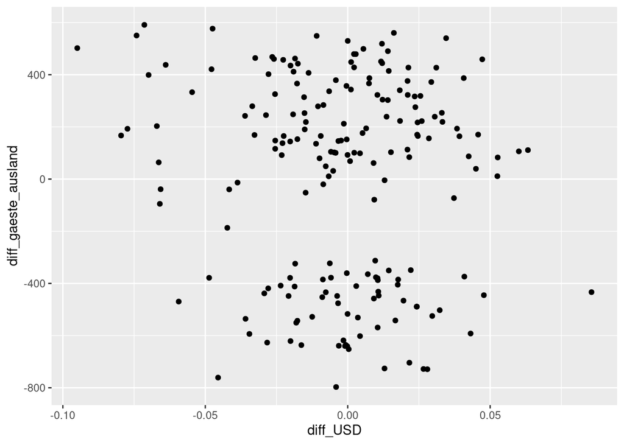

```r
df_01_forex %>%
  ggplot(aes(x = diff_USD, y = diff_gaeste_ausland)) +
  geom_point()
```

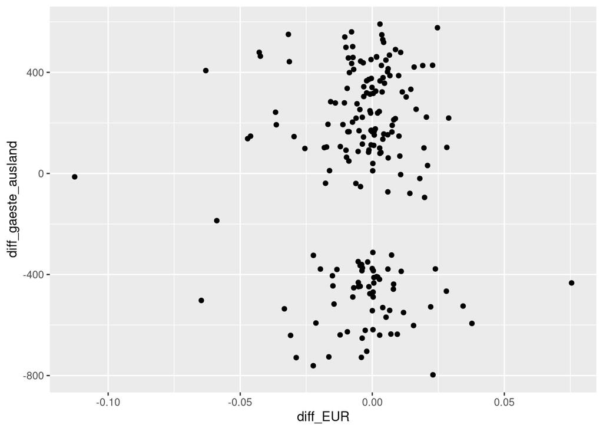

```r
df_01_forex %>%
  ggplot(aes(x = diff_EUR, y = diff_gaeste_ausland)) +
  geom_point()
```

```r
cor(df_01_forex$diff_USD, df_01_forex$diff_gaeste_ausland)
```

```
## [1] -0.0973
```

```r
df_01_forex %>% select_if(is.numeric) %>% cor() %>% round(digits = 2)
```

```
##                          EUR   USD diff_USD diff_EUR diff_USD12 diff_EUR12
## EUR                     1.00  0.63    -0.04     0.10      -0.12       0.34
## USD                     0.63  1.00     0.01     0.06       0.17       0.17
## diff_USD               -0.04  0.01     1.00     0.23       0.32       0.07
## diff_EUR                0.10  0.06     0.23     1.00       0.01       0.33
## diff_USD12             -0.12  0.17     0.32     0.01       1.00      -0.03
## diff_EUR12              0.34  0.17     0.07     0.33      -0.03       1.00
## anzahl_gaeste_ausland   0.02 -0.07    -0.02    -0.05       0.04      -0.05
## anzahl_gaeste_inland   -0.14 -0.17     0.02    -0.03       0.00      -0.05
## diff_gaeste_ausland     0.02  0.00    -0.10    -0.03       0.01       0.01
## diff_gaeste_inland      0.01  0.00    -0.08    -0.03       0.01       0.00
## diff_gaeste_ausland_12  0.25  0.02     0.02    -0.03       0.18       0.28
## diff_gaeste_inland_12   0.10  0.06    -0.07    -0.02      -0.01       0.11
##                        anzahl_gaeste_ausland anzahl_gaeste_inland
## EUR                                     0.02                -0.14
## USD                                    -0.07                -0.17
## diff_USD                               -0.02                 0.02
## diff_EUR                               -0.05                -0.03
## diff_USD12                              0.04                 0.00
## diff_EUR12                             -0.05                -0.05
## anzahl_gaeste_ausland                   1.00                 0.86
## anzahl_gaeste_inland                    0.86                 1.00
## diff_gaeste_ausland                     0.45                 0.22
## diff_gaeste_inland                      0.54                 0.50
## diff_gaeste_ausland_12                  0.10                -0.02
## diff_gaeste_inland_12                   0.10                 0.10
##                        diff_gaeste_ausland diff_gaeste_inland
## EUR                                   0.02               0.01
## USD                                   0.00               0.00
## diff_USD                             -0.10              -0.08
## diff_EUR                             -0.03              -0.03
## diff_USD12                            0.01               0.01
## diff_EUR12                            0.01               0.00
## anzahl_gaeste_ausland                 0.45               0.54
## anzahl_gaeste_inland                  0.22               0.50
## diff_gaeste_ausland                   1.00               0.83
## diff_gaeste_inland                    0.83               1.00
## diff_gaeste_ausland_12                0.09               0.01
## diff_gaeste_inland_12                 0.13               0.14
##                        diff_gaeste_ausland_12 diff_gaeste_inland_12
## EUR                                      0.25                  0.10
## USD                                      0.02                  0.06
## diff_USD                                 0.02                 -0.07
## diff_EUR                                -0.03                 -0.02
## diff_USD12                               0.18                 -0.01
## diff_EUR12                               0.28                  0.11
## anzahl_gaeste_ausland                    0.10                  0.10
## anzahl_gaeste_inland                    -0.02                  0.10
## diff_gaeste_ausland                      0.09                  0.13
## diff_gaeste_inland                       0.01                  0.14
## diff_gaeste_ausland_12                   1.00                  0.49
## diff_gaeste_inland_12                    0.49                  1.00
```

```r
cor(df_01_forex$diff_EUR, df_01_forex$diff_gaeste_ausland)
```

```
## [1] -0.03034
```

```r
df_01_forex %>% select_if(is.numeric) %>% cor() %>% round(digits = 2)
```

```
##                          EUR   USD diff_USD diff_EUR diff_USD12 diff_EUR12
## EUR                     1.00  0.63    -0.04     0.10      -0.12       0.34
## USD                     0.63  1.00     0.01     0.06       0.17       0.17
## diff_USD               -0.04  0.01     1.00     0.23       0.32       0.07
## diff_EUR                0.10  0.06     0.23     1.00       0.01       0.33
## diff_USD12             -0.12  0.17     0.32     0.01       1.00      -0.03
## diff_EUR12              0.34  0.17     0.07     0.33      -0.03       1.00
## anzahl_gaeste_ausland   0.02 -0.07    -0.02    -0.05       0.04      -0.05
## anzahl_gaeste_inland   -0.14 -0.17     0.02    -0.03       0.00      -0.05
## diff_gaeste_ausland     0.02  0.00    -0.10    -0.03       0.01       0.01
## diff_gaeste_inland      0.01  0.00    -0.08    -0.03       0.01       0.00
## diff_gaeste_ausland_12  0.25  0.02     0.02    -0.03       0.18       0.28
## diff_gaeste_inland_12   0.10  0.06    -0.07    -0.02      -0.01       0.11
##                        anzahl_gaeste_ausland anzahl_gaeste_inland
## EUR                                     0.02                -0.14
## USD                                    -0.07                -0.17
## diff_USD                               -0.02                 0.02
## diff_EUR                               -0.05                -0.03
## diff_USD12                              0.04                 0.00
## diff_EUR12                             -0.05                -0.05
## anzahl_gaeste_ausland                   1.00                 0.86
## anzahl_gaeste_inland                    0.86                 1.00
## diff_gaeste_ausland                     0.45                 0.22
## diff_gaeste_inland                      0.54                 0.50
## diff_gaeste_ausland_12                  0.10                -0.02
## diff_gaeste_inland_12                   0.10                 0.10
##                        diff_gaeste_ausland diff_gaeste_inland
## EUR                                   0.02               0.01
## USD                                   0.00               0.00
## diff_USD                             -0.10              -0.08
## diff_EUR                             -0.03              -0.03
## diff_USD12                            0.01               0.01
## diff_EUR12                            0.01               0.00
## anzahl_gaeste_ausland                 0.45               0.54
## anzahl_gaeste_inland                  0.22               0.50
## diff_gaeste_ausland                   1.00               0.83
## diff_gaeste_inland                    0.83               1.00
## diff_gaeste_ausland_12                0.09               0.01
## diff_gaeste_inland_12                 0.13               0.14
##                        diff_gaeste_ausland_12 diff_gaeste_inland_12
## EUR                                      0.25                  0.10
## USD                                      0.02                  0.06
## diff_USD                                 0.02                 -0.07
## diff_EUR                                -0.03                 -0.02
## diff_USD12                               0.18                 -0.01
## diff_EUR12                               0.28                  0.11
## anzahl_gaeste_ausland                    0.10                  0.10
## anzahl_gaeste_inland                    -0.02                  0.10
## diff_gaeste_ausland                      0.09                  0.13
## diff_gaeste_inland                       0.01                  0.14
## diff_gaeste_ausland_12                   1.00                  0.49
## diff_gaeste_inland_12                    0.49                  1.00
```

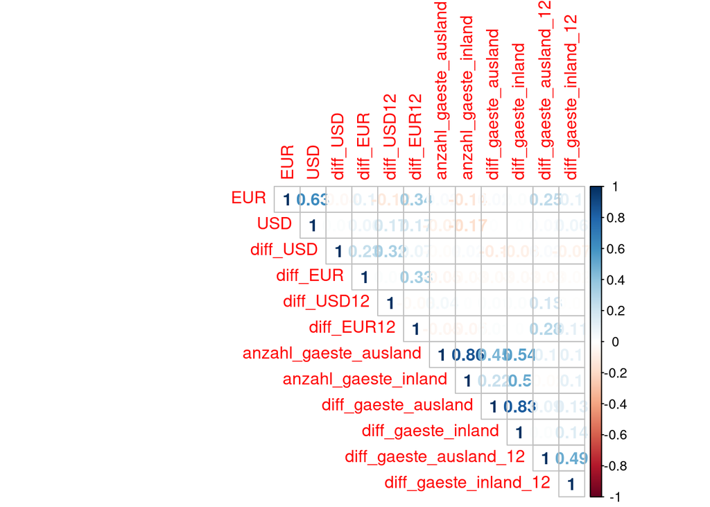

```r
p_load(corrplot)

corrplot((df_01_forex %>% select_if(is.numeric) %>% cor() %>% round(digits = 2)), method = "number", type = "upper")
```

```r
#https://www.statsandr.com/blog/correlogram-in-r-how-to-highlight-the-most-correlated-variables-in-a-dataset/
#devtools::install_github("laresbernardo/lares")
p_load(lares)

corr_cross(df_01_forex, # name of dataset
   #max_pvalue = 0.0005, # display only significant correlations (at 5% level)
  top = 10 # display top 10 couples of variables (by correlation coefficient)
)
```

```
## Returning only the top 10. You may override with the `top` parameter
```

[figure not shown]

```r
corr_var(df_01_forex, # name of dataset
  diff_gaeste_ausland, # name of variable to focus on
  top = 5 # display top 5 correlations
)
```

[figure not shown]

```r
skim(df_01_forex)
```

Data summary

| Name | df_01_forex |
| --- | --- |
| Number of rows | 192 |
| Number of columns | 13 |
| _______________________ |  |
| Column type frequency: |  |
| character | 1 |
| numeric | 12 |
| ________________________ |  |
| Group variables | None |

**Variable type: character**

| skim_variable | n_missing | complete_rate | min | max | empty | n_unique | whitespace |
| --- | --- | --- | --- | --- | --- | --- | --- |
| year_mon | 0 | 1 | 7 | 7 | 0 | 192 | 0 |

**Variable type: numeric**

| skim_variable | n_missing | complete_rate | mean | sd | p0 | p25 | p50 | p75 | p100 | hist |
| --- | --- | --- | --- | --- | --- | --- | --- | --- | --- | --- |
| EUR | 0 | 1 | 1.40 | 0.19 | 1.04 | 1.22 | 1.47 | 1.55 | 1.67 | ▃▆▁▇▇ |
| USD | 0 | 1 | 1.18 | 0.27 | 0.78 | 0.96 | 1.10 | 1.31 | 1.78 | ▇▆▅▁▃ |
| diff_USD | 0 | 1 | 0.00 | 0.03 | -0.09 | -0.02 | 0.00 | 0.02 | 0.09 | ▁▂▇▅▁ |
| diff_EUR | 0 | 1 | 0.00 | 0.02 | -0.11 | -0.01 | 0.00 | 0.01 | 0.08 | ▁▁▇▇▁ |
| diff_USD12 | 0 | 1 | -0.03 | 0.11 | -0.34 | -0.09 | -0.02 | 0.04 | 0.28 | ▁▃▇▅▁ |
| diff_EUR12 | 0 | 1 | -0.03 | 0.07 | -0.22 | -0.08 | -0.02 | 0.02 | 0.09 | ▂▂▅▇▅ |
| anzahl_gaeste_ausland | 0 | 1 | 1624.21 | 431.89 | 679.00 | 1340.07 | 1569.84 | 1883.02 | 2575.84 | ▂▇▇▅▃ |
| anzahl_gaeste_inland | 0 | 1 | 1250.49 | 271.79 | 679.00 | 1010.75 | 1283.94 | 1479.30 | 1763.78 | ▃▆▇▇▃ |
| diff_gaeste_ausland | 0 | 1 | 0.98 | 388.59 | -797.02 | -391.90 | 112.00 | 322.50 | 591.00 | ▃▅▂▇▆ |
| diff_gaeste_inland | 0 | 1 | 1.59 | 273.50 | -557.13 | -170.95 | 26.50 | 223.91 | 547.91 | ▅▅▇▇▃ |
| diff_gaeste_ausland_12 | 0 | 1 | 3.72 | 113.88 | -421.77 | -62.70 | 8.73 | 76.96 | 322.00 | ▁▂▇▆▁ |
| diff_gaeste_inland_12 | 0 | 1 | 12.53 | 49.31 | -115.90 | -18.49 | 9.87 | 37.26 | 155.00 | ▂▅▇▃▁ |

## Visualize

With the following chapter, we inspect the data through visualization. Visualization is a fundamentally human activity. A good visualization will show things that we did not expect, or raise new questions about the data. A good visualization might also hint that you’re asking the wrong question, or you need to collect different data. Visualizations can surprise, but don’t scale particularly well because they require a human to interpret them.

### Availability of night / hotel bed

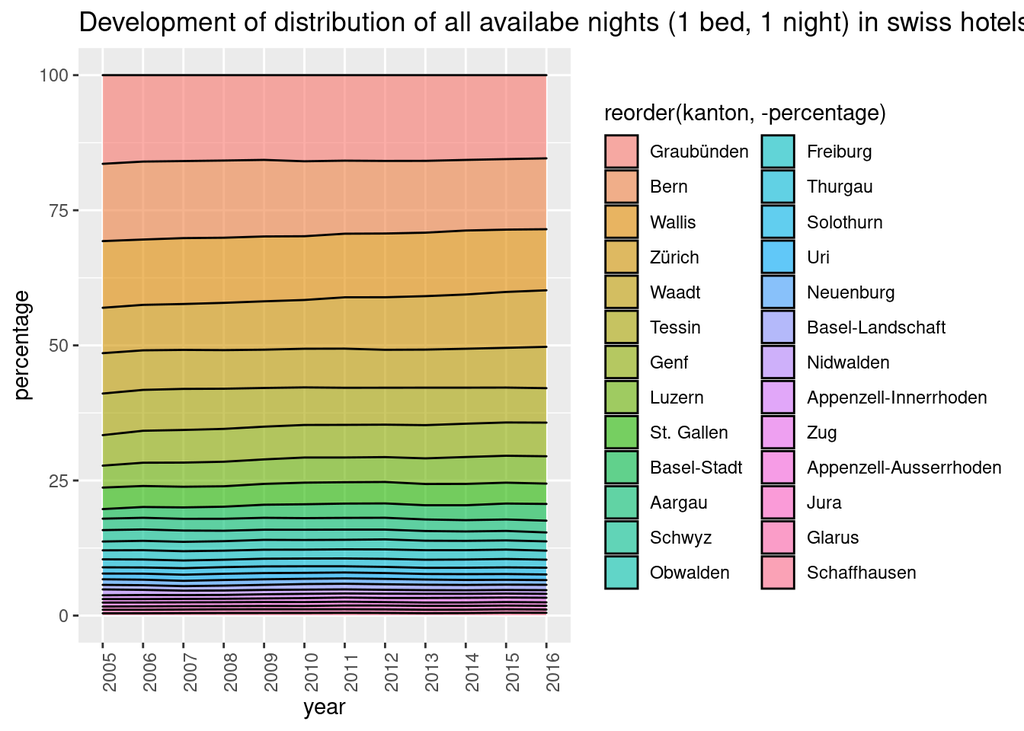

```r
# available hotel bed nights (1 bed for 1 night) sorted and proportional
df_hotel %>%
  filter(kanton != "Schweiz") %>%
  group_by(year, kanton) %>%
  summarise(n = sum(total_bett_year_average)) %>%
  group_by(year) %>%
  mutate(percentage = n / sum(n)*100) %>%
  ggplot(aes(
    x = year,
    y = percentage,
    group = reorder(kanton, -percentage),
    fill = reorder(kanton, -percentage)
  )) +
    geom_area(  alpha = 0.6,
                size = 0.5,
                colour="black",
                linetype = 1,
                size =2) +
  labs(title = "Development of distribution of all availabe nights (1 bed, 1 night) in swiss hotels") +
  theme(axis.text.x = element_text(angle = 90))
```

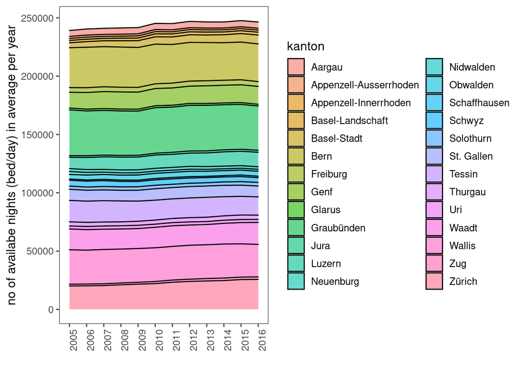

```r
# available hotel bed nights (1 bed for 1 night) alphabetically and absolut
df_hotel %>%
  filter(kanton != "Schweiz") %>%
  group_by(year, kanton) %>%
  summarise(n = sum(total_bett_year_average))%>%
  group_by(year) %>%
  ggplot(aes(
    x = year,
    y = n,
    group = kanton,
    fill = kanton,
  )) +
  geom_area(alpha = 0.6,
            size = 0.5,
            colour="black") +
  ylab("no of availabe nights (bed/day) in average per year") +
  xlab(" ") +
  theme(plot.title = "Percentage of all availabe hotelbeds in switzerland") +
  theme_few() +
  theme(axis.text.x = element_text(angle = 90))
```

### Hotelguests over the year per month and origin

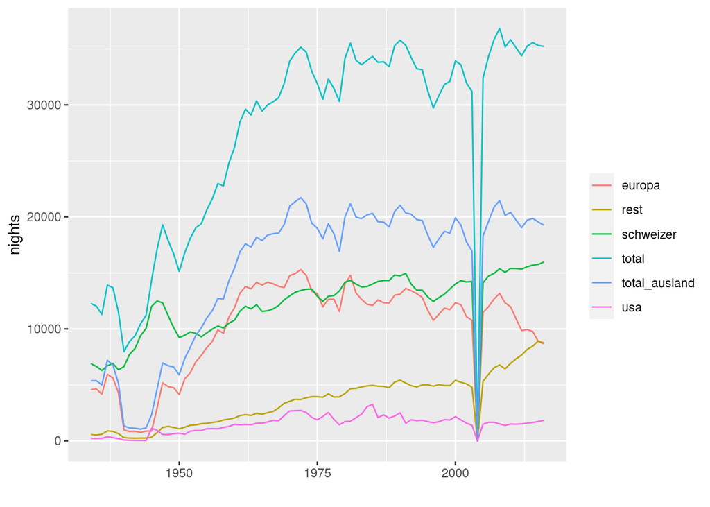

```r
# line chart total over years
df_ln_ausland_year %>%
  gather(key = herkunft, value = naechte, -jahr) %>%
  ggplot(aes(
    x = jahr,
    y = naechte,
    color = herkunft,
    group = herkunft
  )) +
  geom_line() +
  ylab("nights") +
  xlab(" ") +
  scale_color_discrete(name = " ")
```

#### Monthly peaks of guests over the years

In the following chapter we will answer the question in which month the most tourist visit Switzerland respectively swiss inhabitants spend their holidays in local hotels. - august and july seem to be the most attracitve months to visit switzerland - swiss take their somerbreak most often in july - februar and march (skiing season) shows clearly trends of more visitors from abroad over time

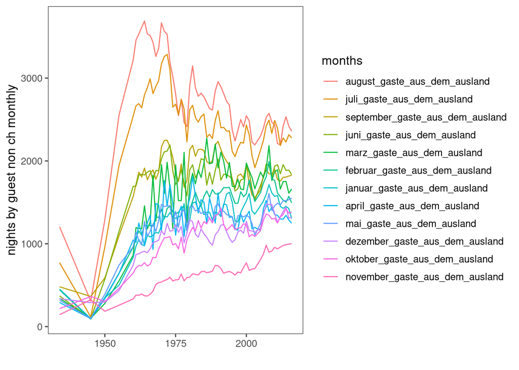

```r
# monthly distribution of foreign guests (linechart)
df_ln_month %>%
  filter(str_detect(herkunft, "ausland")) %>%
  ggplot() +
  geom_line(aes(
    x = jahre,
    y = naechte,
    group = reorder(herkunft, -naechte),
    color = reorder(herkunft, -naechte)
  )) +
  scale_color_discrete(name = "months") +
  ylab("nights by guest non ch monthly") +
  xlab(" ") +
  theme_few()
```

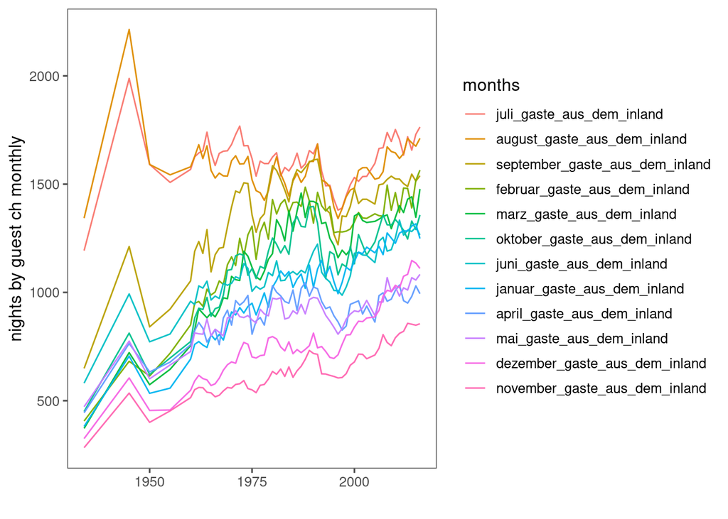

```r
# monthly distribution of ch guests (boxplot)
df_ln_month %>%
  filter(str_detect(herkunft, "inland")) %>%
  ggplot() +
  geom_line(aes(
    x = jahre,
    y = naechte,
    group = reorder(herkunft, -naechte),
    color = reorder(herkunft, -naechte)
  )) +
  scale_color_discrete(name = "months") +
  ylab("nights by guest ch monthly") +
  xlab(" ") +
  theme_few()
```

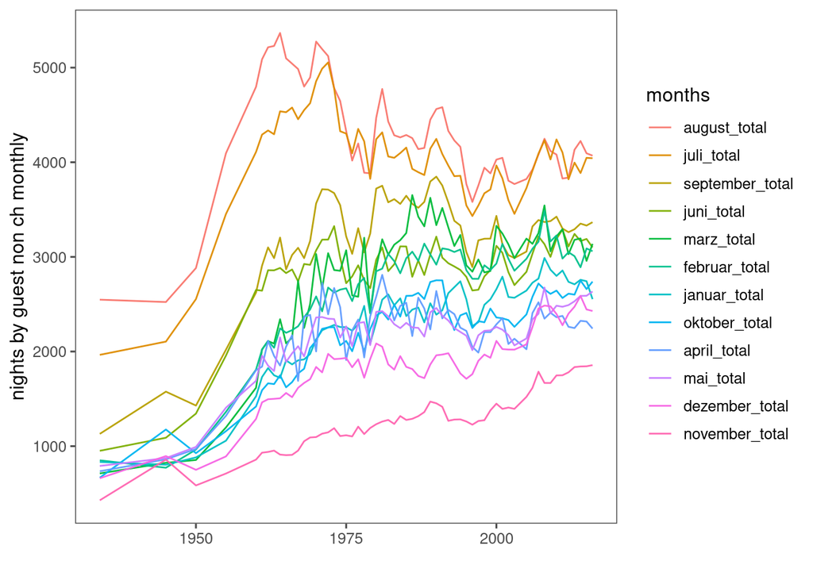

```r
# monthly distribution of foreign guests (linechart)

df_ln_month %>%
  filter(str_detect(herkunft, "total")) %>%
  ggplot() +
  geom_line(aes(
    x = jahre,
    y = naechte,
    group = reorder(herkunft, -naechte),
    color = reorder(herkunft, -naechte)
  )) +
  scale_color_discrete(name = "months") +
  ylab("nights by guest non ch monthly") +
  xlab(" ") +
  theme_few()
```

#### How are the peaks from visitors distributed per month?

The following example show how the distribution of a multi dimensional data frame can be examined. Beside the normal “boxplot” method, ridge charts show how the monthly guests are distributed over the years (not chronologically).

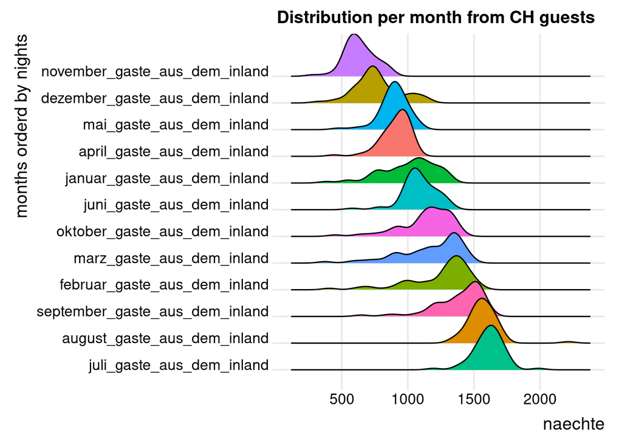

```r
# monthly ridge chart distribution from CH guests
df_ln_month %>%
  filter(str_detect(herkunft, 'inland')) %>%
  ggplot(aes(x = naechte,
             y = reorder(herkunft, -naechte),
             fill = herkunft)) +
  geom_density_ridges() +
  theme_ridges() +
  theme(legend.position = "none") +
  ggtitle("Distribution per month from CH guests") +
  ylab('months orderd by nights')
```

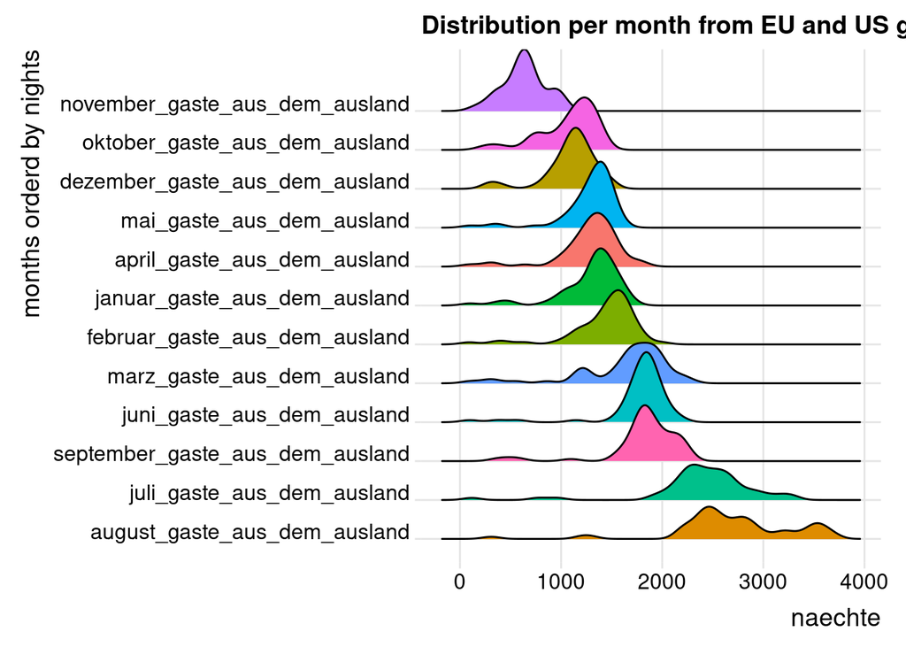

```r
# monthly ridge chart distribution from CH guests
df_ln_month %>%
  filter(str_detect(herkunft, 'ausland')) %>%
  ggplot(aes(x = naechte,
             y = reorder(herkunft, -naechte),
             fill = herkunft)) +
  geom_density_ridges() +
  theme_ridges() +
  theme(legend.position = "none") +
  ggtitle("Distribution per month from EU and US guests") +
  ylab('months orderd by nights')
```

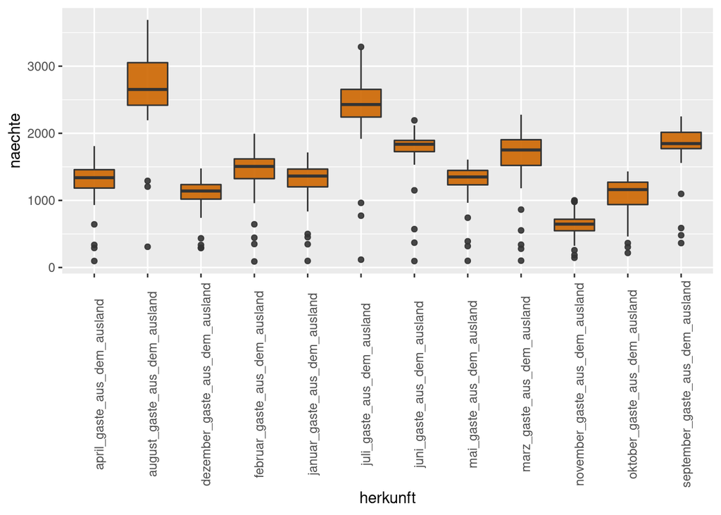

```r
# monthly distribution of foreign guests (boxplot)

df_ln_month %>%
  filter(str_detect(herkunft, "ausland")) %>%
  ggplot() +
  geom_boxplot(aes(
    x = herkunft,
    y = naechte,
    group = reorder(herkunft, -naechte)
  )) +
  theme(axis.text.x = element_text(angle = 90))
```

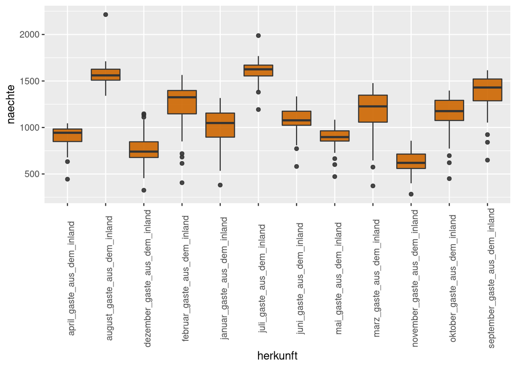

```r
# monthly distribution of ch guests (boxplot)
df_ln_month %>%
  filter(str_detect(herkunft, "inland")) %>%
  ggplot() +
  geom_boxplot(aes(
    x = herkunft,
    y = naechte,
    group = reorder(herkunft, -naechte)
  )) +
  theme(axis.text.x = element_text(angle = 90))
```

#### Currency charts

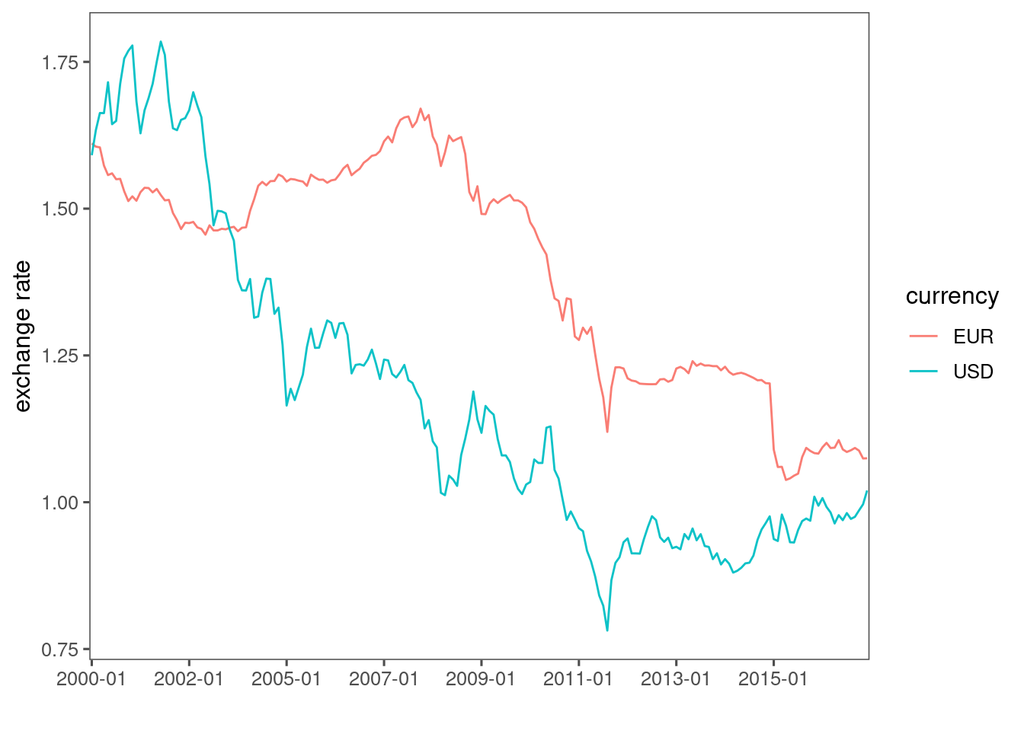

```r
#Function to show every n-th element of discrete axis
every_nth = function(n) {
  return(function(x) {x[c(TRUE, rep(FALSE, n - 1))]})
}

# line chart of USD/CHF and EUR/CHF exchange rates
df_01_forex %>%
  select(EUR, USD, year_mon) %>%
  gather( key = currency,
          value = rate,
          - year_mon) %>%
  ggplot() +
  geom_line(aes(
    x = year_mon,
    y = rate,
    group = currency,
    color = currency
  )) +
  scale_x_discrete(breaks = every_nth(n = 24)) +
  theme_few() +
  ylab("exchange rate") +
  xlab(" ")
```

## Model

Models are complementary tools to visualisation. Once we have made our questions sufficiently precise, you can use a model to answer them. Models are a fundamentally mathematical or computational tool, so they generally scale well. But every model makes assumptions, and by its very nature a model cannot question its own assumptions. That means a model cannot fundamentally surprise you.

```r
#lm model for 1 month lag diff (EUR)
lm01 <- lm(anzahl_gaeste_ausland ~ diff_gaeste_ausland + diff_EUR, data = df_01_forex)
summary(lm01)
```

```
##
## Call:
## lm(formula = anzahl_gaeste_ausland ~ diff_gaeste_ausland + diff_EUR,
##     data = df_01_forex)
##
## Residuals:
##    Min     1Q Median     3Q    Max
## -754.6 -248.4  -41.9  227.6  916.2
##
## Coefficients:
##                      Estimate Std. Error t value             Pr(>|t|)
## (Intercept)         1621.4314    28.2747   57.35 < 0.0000000000000002 ***
## diff_gaeste_ausland    0.4961     0.0723    6.86       0.000000000093 ***
## diff_EUR            -868.9909  1502.2995   -0.58                 0.56
## ---
## Signif. codes:  0 '***' 0.001 '**' 0.01 '*' 0.05 '.' 0.1 ' ' 1
##
## Residual standard error: 388 on 189 degrees of freedom
## Multiple R-squared:  0.202,  Adjusted R-squared:  0.193
## F-statistic: 23.9 on 2 and 189 DF,  p-value: 0.00000000057
```

```r
#lm model for 12 month lag diff (EUR)
lm02 <- lm(anzahl_gaeste_ausland ~ diff_gaeste_ausland_12 + diff_EUR12, data = df_01_forex)
summary(lm02)
```

```
##
## Call:
## lm(formula = anzahl_gaeste_ausland ~ diff_gaeste_ausland_12 +
##     diff_EUR12, data = df_01_forex)
##
## Residuals:
##    Min     1Q Median     3Q    Max
## -918.1 -295.4  -48.7  234.6  937.7
##
## Coefficients:
##                        Estimate Std. Error t value            Pr(>|t|)
## (Intercept)            1606.235     34.537   46.51 <0.0000000000000002 ***
## diff_gaeste_ausland_12    0.460      0.285    1.61                0.11
## diff_EUR12             -486.948    440.956   -1.10                0.27
## ---
## Signif. codes:  0 '***' 0.001 '**' 0.01 '*' 0.05 '.' 0.1 ' ' 1
##
## Residual standard error: 431 on 189 degrees of freedom
## Multiple R-squared:  0.016,  Adjusted R-squared:  0.00556
## F-statistic: 1.53 on 2 and 189 DF,  p-value: 0.218
```

```r
anova(lm01, lm02)
```

|  | Res.Df | RSS | Df | Sum of Sq | F | Pr(>F) |
| --- | --- | --- | --- | --- | --- | --- |
| 1 | 189 | 28441722 | NA | NA | NA | NA |
| 2 | 189 | 35057723 | 0 | -6616002 | NA | NA |

# further information

Please see second file for application examples of “shiny”